# Repro R PA1

```

```r
getwd()
```

```
## [1] "C:/Users/owner/Documents/Coursera/Repro R PA1"
```

Download the file

```r
download.file("http://d396qusza40orc.cloudfront.net/repdata%2Fdata%2Factivity.zip","Activity")
```

Examine Data file Note 1st column is steps, 2nd is date (YYYY-MM-DD format), and 3d is 5 minute time interval

```r
activity <- read.csv("C:/Users/owner/Documents/Coursera/activity.csv",stringsAsFactors =F)
str(activity)
```

```
## 'data.frame':    17568 obs. of  3 variables:
##  $ steps   : int  NA NA NA NA NA NA NA NA NA NA ...
##  $ date    : chr  "2012-10-01" "2012-10-01" "2012-10-01" "2012-10-01" ...
##  $ interval: int  0 5 10 15 20 25 30 35 40 45 ...
```

Note the data is measured for 61 days Must convert dates from strings to dates

```r
activity$date <- as.Date(activity$date)
activity$steps <- as.numeric(activity$steps)
```

Q2 What is the mean total number of steps per day?

```r
library(dplyr)
```

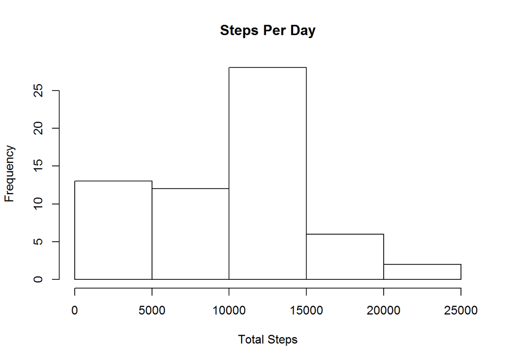

```r
steps.per.day <- group_by(activity,date)
steps.total <- summarize(steps.per.day, Total_Steps = sum(steps,na.rm=T))
hist(steps.total$Total_Steps, main = "Steps Per Day", xlab = "Total Steps")
```

```r
summary(steps.total)
```

```
##       date             Total_Steps
##  Min.   :2012-10-01   Min.   :    0
##  1st Qu.:2012-10-16   1st Qu.: 6778
##  Median :2012-10-31   Median :10395
##  Mean   :2012-10-31   Mean   : 9354
##  3rd Qu.:2012-11-15   3rd Qu.:12811
##  Max.   :2012-11-30   Max.   :21194
```

The Median is 10,395 and the mean is 9354 steps per day

Q3. What is the average daily activity pattern?

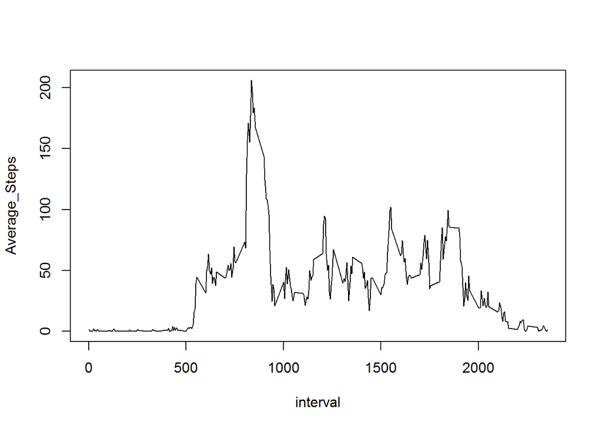

```r
steps.per.interval <- group_by(activity,interval)
avg.steps <- summarize(steps.per.interval, Average_Steps = mean(steps,na.rm=T))
plot(avg.steps, type ="l")
```

Find max level of steps

```r
summary(avg.steps)
```

```
##     interval      Average_Steps
##  Min.   :   0.0   Min.   :  0.000
##  1st Qu.: 588.8   1st Qu.:  2.486
##  Median :1177.5   Median : 34.113
##  Mean   :1177.5   Mean   : 37.383
##  3rd Qu.:1766.2   3rd Qu.: 52.835
##  Max.   :2355.0   Max.   :206.170
```

Max level of average steps is 206.170. Find which interval that is?

```r
 a <- arrange (avg.steps,desc(Average_Steps))
head(a)
```

```
## Source: local data frame [6 x 2]
##
##   interval Average_Steps
## 1      835      206.1698
## 2      840      195.9245
## 3      850      183.3962
## 4      845      179.5660
## 5      830      177.3019
## 6      820      171.1509
```

Interval 835 has the highest average # of steps

Q4. Calculate and report the total number of missing values in the dataset (i.e. the total number of rows with NAs)

```r
sum(is.na(activity$steps))
```

```
## [1] 2304
```

Devise a strategy for “filling in” NA values. I choose to use the mean value for that 5 minute interval. First, create a vector of average steps taken for all 5 minute intervals in the activity df. Recall avg.steps has the average for each 5 minute interval in a day, and there are 61 days

```r
avg.step.v <- (rep(avg.steps$Average_Steps, times = 61))
```

Add avg step vector to df, then replace NA’s with corresponding interval averages

```r
filled.activity <- cbind(activity,avg.step.v)
filled.activity$steps[is.na(filled.activity$steps)] <- filled.activity$avg.step.v[is.na(filled.activity$steps)]
```

Plot histogram of steps per day and calculate mean and median as before, only using “filled” data

[figure not shown]

```r
summary(steps.total)
```

```
##       date             Total_Steps
##  Min.   :2012-10-01   Min.   :    0
##  1st Qu.:2012-10-16   1st Qu.: 6778
##  Median :2012-10-31   Median :10395
##  Mean   :2012-10-31   Mean   : 9354
##  3rd Qu.:2012-11-15   3rd Qu.:12811
##  Max.   :2012-11-30   Max.   :21194
```

Add new factor to filled df

```r
f.activty.we <- cbind(filled.activity,fwd)
str(f.activty.we)
```

```
## 'data.frame':    17568 obs. of  5 variables:
##  $ steps     : num  1.717 0.3396 0.1321 0.1509 0.0755 ...
##  $ date      : Date, format: "2012-10-01" "2012-10-01" ...
##  $ interval  : int  0 5 10 15 20 25 30 35 40 45 ...
##  $ avg.step.v: num  1.717 0.3396 0.1321 0.1509 0.0755 ...
##  $ fwd       : Factor w/ 2 levels "Weekday","Weekend": 1 1 1 1 1 1 1 1 1 1 ...
```

Filter into two diff df’s for Weekend or Weekday

```r
We.activity <- filter(f.activty.we, fwd == "Weekend")
Wd.activity <- filter(f.activty.we, fwd == "Weekday")
```

Group by interval and compute mean steps

```r
We.steps.per.interval <- group_by(We.activity,interval)
We.avg.steps <- summarize(We.steps.per.interval, Average_Steps_We = mean(steps))
Wd.steps.per.interval <- group_by(Wd.activity,interval)
Wd.avg.steps <- summarize(Wd.steps.per.interval, Average_Steps = mean(steps))
```

Create Panel of 2 seperate plots for Average Steps per interval, for Weekends and Weekdays.

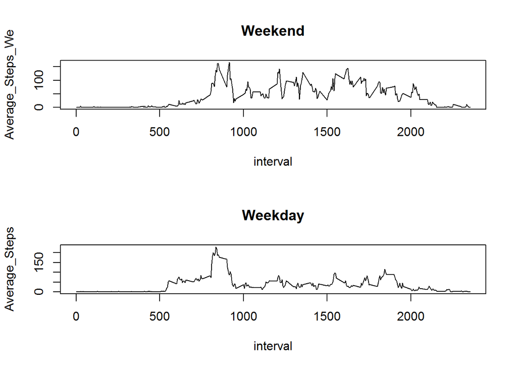